# Discerning Prosper Interest Rates by Abhishek Anirudhan

# Multivariate Plots Section

I trained two linear models:

One with Loan Amount, Income, Employment Status and Purpose of the loan - this model explained only 10% of the variance.  
I updated this model with the Credit Score and was able to explain 30% of the variance.

```
##
## Calls:
## model_1: lm(formula = BorrowerRate ~ LoanOriginalAmount + StatedMonthlyIncome +
##     EmploymentStatus + LoanPurpose, data = pld2)
## model_2: lm(formula = BorrowerRate ~ LoanOriginalAmount + StatedMonthlyIncome +
##     EmploymentStatus + LoanPurpose + CreditScoreMean, data = pld2)
##
## =======================================================================
##                                                   model_1    model_2
## -----------------------------------------------------------------------
##   (Intercept)                                     0.221***   0.605***
##                                                  (0.001)    (0.002)
##   LoanOriginalAmount                             -0.000***  -0.000***
##                                                  (0.000)    (0.000)
##   StatedMonthlyIncome                            -0.000***  -0.000***
##                                                  (0.000)    (0.000)
##   EmploymentStatus: Full-time/Employed           -0.016***  -0.021***
##                                                  (0.001)    (0.001)
##   EmploymentStatus: Not available/Employed       -0.005***  -0.036***
##                                                  (0.001)    (0.001)
##   EmploymentStatus: Not employed/Employed         0.029***   0.037***
##                                                  (0.002)    (0.002)
##   EmploymentStatus: Other/Employed                0.008***   0.011***
##                                                  (0.001)    (0.001)
##   EmploymentStatus: Part-time/Employed           -0.027***  -0.033***
##                                                  (0.002)    (0.002)
##   EmploymentStatus: Retired/Employed             -0.017***  -0.011***
##                                                  (0.003)    (0.002)
##   EmploymentStatus: Self-employed/Employed        0.003**    0.007***
##                                                  (0.001)    (0.001)
##   LoanPurpose: Debt consolidation/Not available   0.013***   0.030***
##                                                  (0.001)    (0.001)
##   LoanPurpose: Home improvement/Not available     0.016***   0.045***
##                                                  (0.001)    (0.001)
##   LoanPurpose: Business/Not available             0.023***   0.049***
##                                                  (0.001)    (0.001)
##   LoanPurpose: Personal loan/Not available       -0.005**    0.005***
##                                                  (0.002)    (0.001)
##   LoanPurpose: Student use/Not available          0.015***   0.029***
##                                                  (0.003)    (0.002)
```

[output cut: 29 more lines]

```
##                                                  (0.003)    (0.002)
##   CreditScoreMean                                           -0.001***
##                                                             (0.000)
## -----------------------------------------------------------------------
##   R-squared                                            0.1        0.3
##   adj. R-squared                                       0.1        0.3
##   sigma                                                0.1        0.1
##   F                                                  617.4     1921.1
##   p                                                    0.0        0.0
##   Log-likelihood                                  139303.6   154238.1
##   Deviance                                           539.6      413.0
##   AIC                                            -278545.3  -308412.2
##   BIC                                            -278246.9  -308104.3
##   N                                               111682     111680
## =======================================================================
```

Given that the models above were only able to explain 30% of the variation in the borrower’s rate, I decided to look for additional factors that might affect the determination of borrowers rate.

This time I decide to rely on Prospers measure of credit risk: Prosper Score. Prosper Score is calculated by taking into account repayment history of previously taken loans.

```
##    Min. 1st Qu.  Median    Mean 3rd Qu.    Max.    NA's
##    1.00    4.00    6.00    5.95    8.00   11.00   29084
```

Since Prosper Scores were awarded only after May-2009, I will only be looking at data from this time frame.

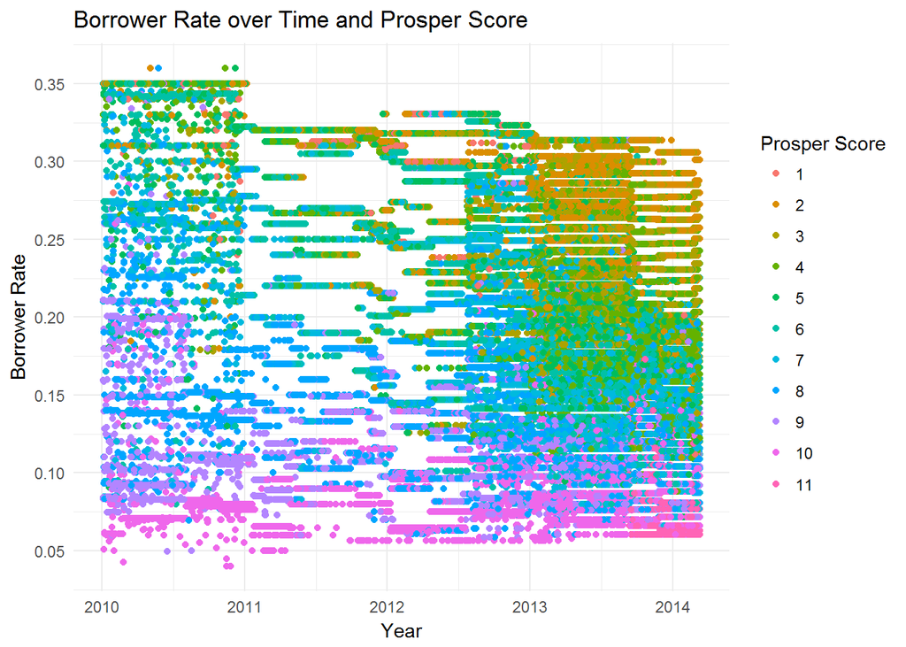

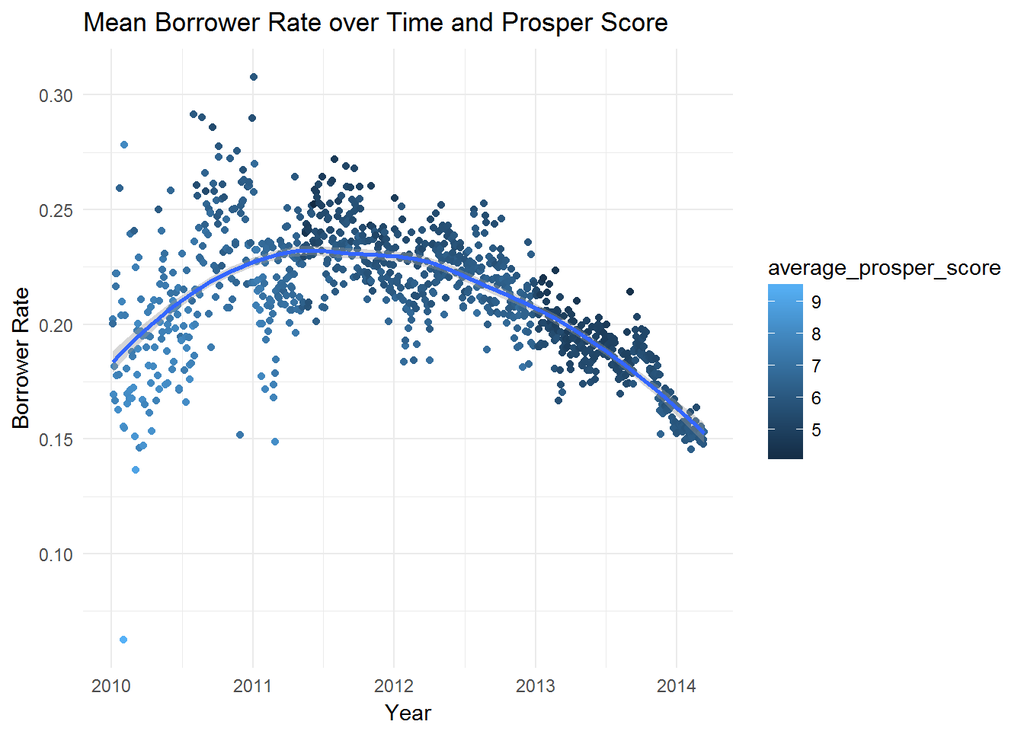

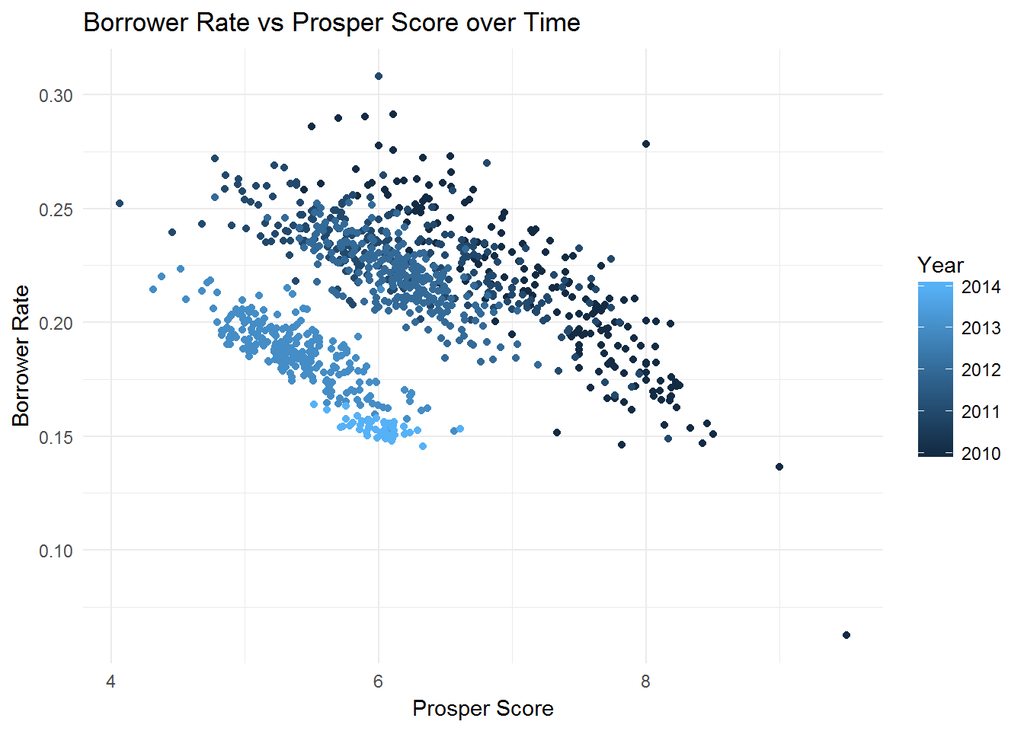

From a couple of plots I can see that the Prosper Score awarded has gone down - on average - over time. I also observed clustering of observations.

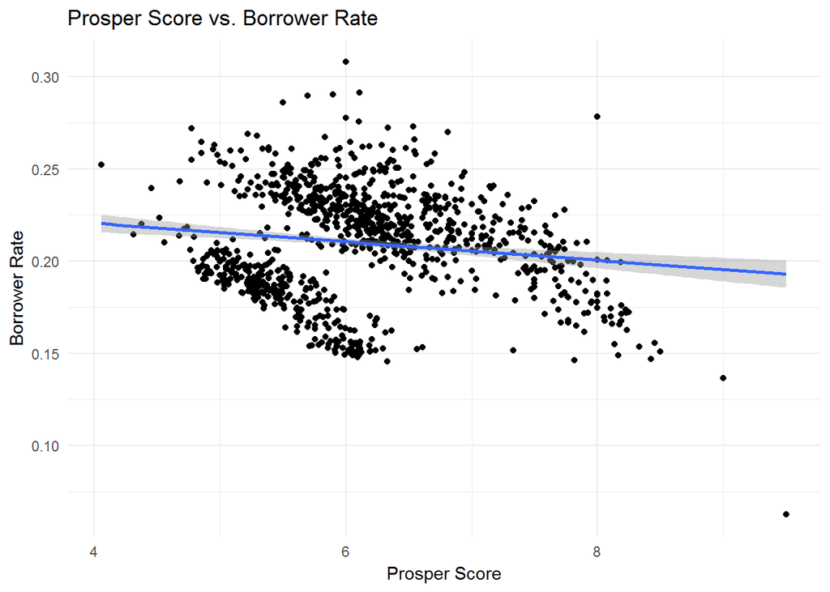

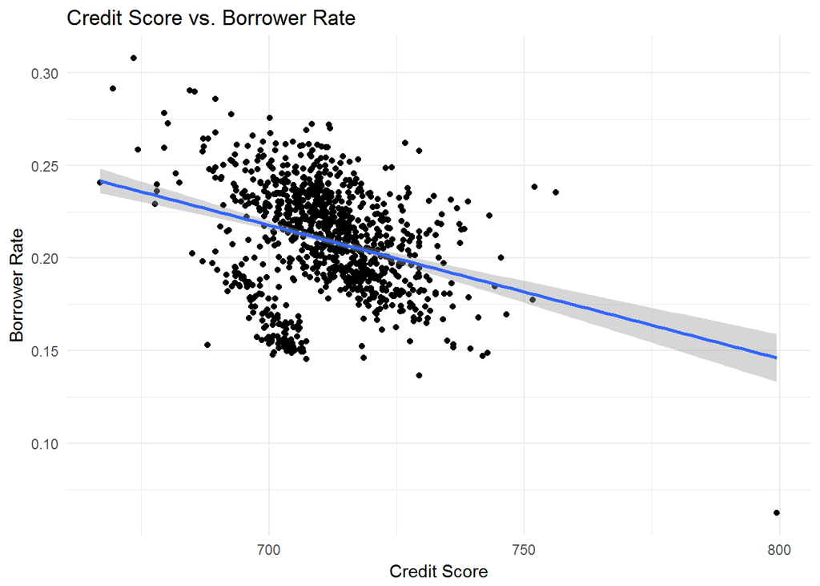

The two plots above seem to have a better structure than the plots in the previous section, and I think it will be worthwhile to train linear models employing them.

```
##
## Calls:
## model_3: lm(formula = BorrowerRate ~ ProsperScore, data = pld2)
## model_4: lm(formula = BorrowerRate ~ ProsperScore + CreditScoreMean, data = pld2)
##
## =========================================
##                     model_3    model_4
## -----------------------------------------
##   (Intercept)       0.317***   0.645***
##                    (0.001)    (0.003)
##   ProsperScore     -0.020***  -0.017***
##                    (0.000)    (0.000)
##   CreditScoreMean             -0.000***
##                               (0.000)
## -----------------------------------------
##   R-squared              0.4        0.5
##   adj. R-squared         0.4        0.5
##   sigma                  0.1        0.1
##   F                  61989.9    43399.7
##   p                      0.0        0.0
##   Log-likelihood    123078.5   129702.0
##   Deviance             273.1      233.6
##   AIC              -246151.1  -259396.0
##   BIC              -246123.1  -259358.6
##   N                  84853      84853
## =========================================
```

I can see that I get better models this time around.

When I looked at Borrower Rate vs Prosper Score over time, I found clustering. This indicates that Time could be an important factor explaining Borrower Rates.

```
##
## Calls:
## model_5: lm(formula = BorrowerRate ~ ProsperScore + CreditScoreMean +
##     Loan_origination_year, data = pld2)
## model_6: lm(formula = BorrowerRate ~ ProsperScore + CreditScoreMean +
##     Loan_origination_quarter, data = pld2)
##
## ==================================================
##                              model_5    model_6
## --------------------------------------------------
##   (Intercept)               48.361***  49.841***
##                             (0.257)    (0.262)
##   ProsperScore              -0.019***  -0.019***
##                             (0.000)    (0.000)
##   CreditScoreMean           -0.000***  -0.000***
##                             (0.000)    (0.000)
##   Loan_origination_year     -0.024***
##                             (0.000)
##   Loan_origination_quarter             -0.024***
##                                        (0.000)
## --------------------------------------------------
##   R-squared                       0.6        0.7
##   adj. R-squared                  0.6        0.7
##   sigma                           0.0        0.0
##   F                           52132.7    52621.9
##   p                               0.0        0.0
##   Log-likelihood             144143.1   144400.4
##   Deviance                      166.2      165.2
##   AIC                       -288276.2  -288790.9
##   BIC                       -288229.5  -288744.1
##   N                           84853      84853
## ==================================================
```

We get a slighty better model that explains about 60% of the variance in the Borrower Rate.

We can fine-tune this model by looking at time in fiscal quarters. This results in a yet better model that explains about 70% of the variance in the Borrower Rate

# Multivariate Analysis

### Talk about some of the relationships you observed in this part of the investigation. Were there features that strengthened each other in terms of looking at your feature(s) of interest? Were there any interesting or surprising interactions between features?

I can see in the plot of Prosper Score vs Borrower Rate over Time that there are clusters of loans:  
The loans awarded 2013 and 2014 are concentrated and fall between 4 and 6 clocking borrower rates approximately between 15% and 22%;  
The loans awarded in 2012 are also concentrated and have scores between 5 and 7, with borrower rates between 17% and 25%;  
The scores and borrower rates for loans before 2012 are more spread out.

### OPTIONAL: Did you create any models with your dataset? Discuss the strengths and limitations of your model.

Yes, I created a few models, best of which comes with an R-squared of 0.7. This explains 70% of the variation in the borrower rate. Which is a good metric to understand the anatomy of how Prosper borrower rates are determined.

However, the data set was riddled with missing values, and the model was trained on a subset of the original data set. This could take away accuracy.

All in all, the model is good to understand what determined borrowe rates - Prosper Score (Calculated based on past repayment record), Credit Score and the time of the year the loan was taken.

A major limiting factor for this model is that it is not a very robust predictive model.

# Final Plots and Summary

### Plot One

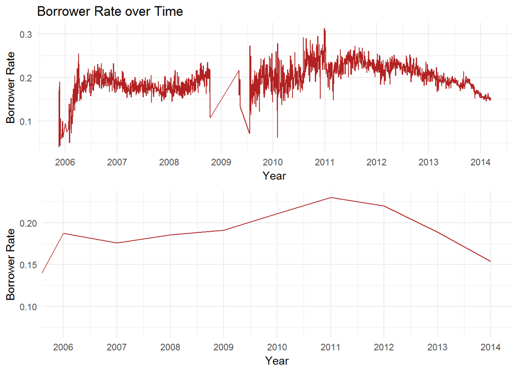

### Description One

I made two plots: one, borrower rate over time, and two, the average borrower rates. The Borrower Rate is highly volatile, but we can see a smooth trend - the rate, on average, gradually climbed from 2007 - 2011, and began a noticeable decent from 2011 - 2014.

### Plot Two

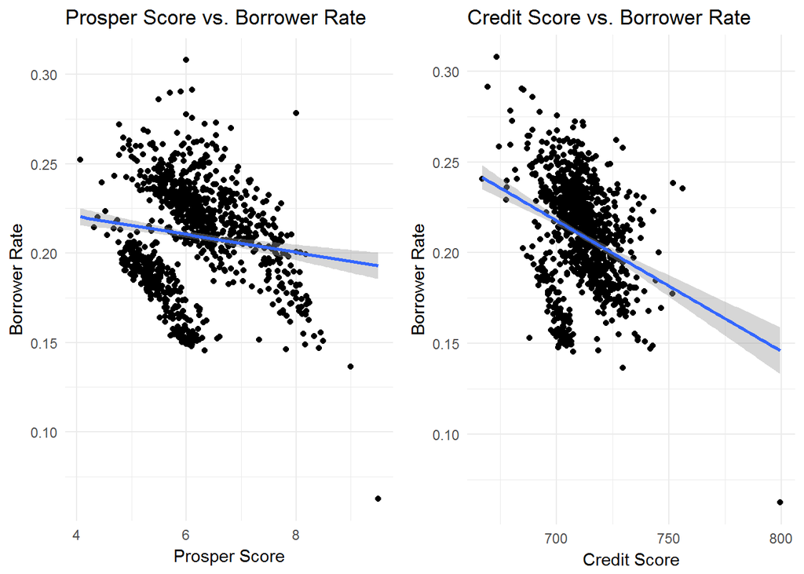

### Description Two

Of the variables explored, Prosper Score and the Credit Score do the best job of explaining the Borrower Rate. Prosper Score is a credit score assigned by Prosper to assess credit risk, and the credit score is also a risk metric. Put together, they were able to explain about 50% of the variation in the interest rates - with a R-squared of 0.5.

Since interest rates are a compensation for risk, these metrics do a neat job of explaining some variation.

### Plot Three

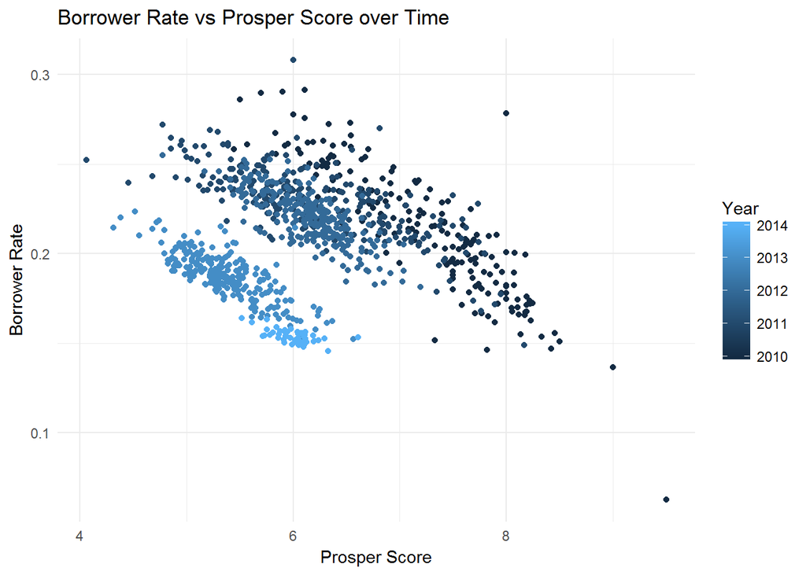

### Description Three

Clustering by time reveals that time could help explain variation in the borrower rate.

I plotted Borrower Rate vs Prosper Score. I adopted an unconventional method of color coding data points by year to look for clustering.

# Reflection

The Prosper Loan Dataset consists of information relating to 113937 crowd-sourced loans spread over 81 variables from 2005 to 2014. The first thing I encountered whilst exploring the dataset was empty cells - which I had to replace with NAs. I then dropped variables with high number of NAs from the analysis.

I went through the variable descriptions, and started plotting to get a sense of the borrower’s profile and characteristics of the loans. The plot for borrowers rate caught my eye. I saw that each borrower got a custom rate, and proceeded to understand what determines the rate offered.

On visiting the Prosper [website](https://www.prosper.com/borrower/#/prospect/registration) I found that Prosper promts you to enter information regarding the required Loan Amount, Employment Status, Purpose of the Loan and Income. I then went on to explore these variables and a few others.

While I got an approximate of what could be driving the borrower rate in some instances (like Unemployed and Non-homeowners get offered higher rates on average), I was mostly stuck with weak relationships between the borrower rate and other variables. I hypothesized that the weak relationship was on account that any standalone variable could not explain the Borrower Rate, but maybe a combination of variables could - however, this looked unlikely given the bivariate plots.

As expected, the linear model came with an R-squared value of 0.3. At this point, I decided to take a look at other variables that might explain the borrower rate better. I found these variables to be the Prosper Score, Credit Score and the time. The final model could explain 70% of the variance. However it’s limitations are that it was based on a dataset riddled with missing values, leading to loss in accuracy. The model is not a robust predictive model.

I intend to take this analysis further by implementing Machine Learning algorithms - including methods like K-nearest neighbors, Support Vector Machines (Using RBF Kernels) and Random Forests - to explore the same variables, to better discern any relationships.